# Communicate Data Findings: 2019 Ford Go-Bike Project

### Udacity DataAnalysis NanoDegree Feb-2021

### Prepared By: Amr Ibrahim (amr.ibrahim2011@gmail.com)

## Investigation Overview

> Ford GoBike, the San Francisco Bay Area’s new regional bike share network, is a public-private partnership between the Metropolitan Transportation Commission and Motivate. Motivate, the global leader in bike share, operates tens of thousands of bikes across four continents.

> In this investigation, I will go deeper on the 2019 dataset and focus my study on the biking duration and the preferred hour of the day and day of the week for bikers. Also I will investiage the bikers data like age, gender and bikers' types to study the effect of these data on the biking duration.

## Dataset Overview

> The dataset contains 183215 observations, and has 14 columns focusing on the bike trip details; the trip duration, start and end times, start and end stations info, and some informations related to the users. Some observations were eliminated from the dataset due to presence of nan values or outliers.

## Distribution of Rides Durations

> As shown on plot below, the peak of trip duration is on range of 7-10 mins, we can see also that few trips lasts for 1-2 mins on the lower limit and few trips lasts more than 60 mins on the upper limit.

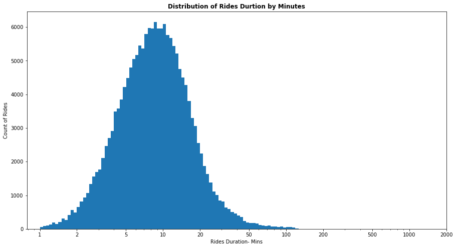

## Trip Duration and Member Age Relationship

> In this part of investigation, I want to investigate the relationship of the trip duration and members' ages.

> From the plot below, we have concluded that from age 20 to 40, the duration of major trips was ranging between 2 mins to 30 mins and the trip duration range is narrowing as the age increased, this is obviously described with the duration_min vs age on the log scale as it looks like a horizontal cone which tends to narrow as the age of the member increased.

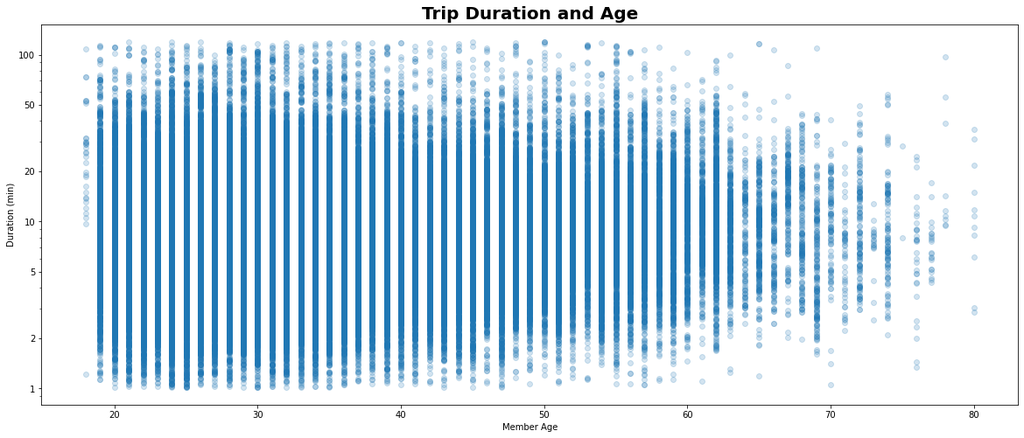

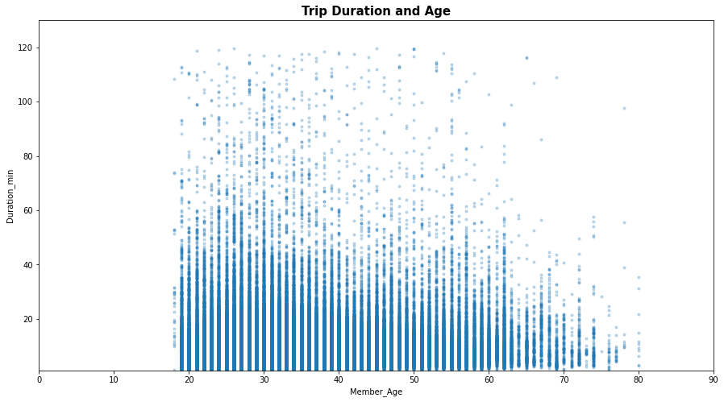

# Hourly usage of the bike share system per user type

> At this part, I want to investigte the hourly usage of the bike system per the user type and show the peak or rush hours for both types.

> As shown at the below plot, we can notice that the rush hours for both user types are 5 P.M and 8 A.M and those two rush hours are matching with the rush hours of whole dataset but obviously the number of trips for subscriber users at those two hours are larger than same two hours for the customer users.

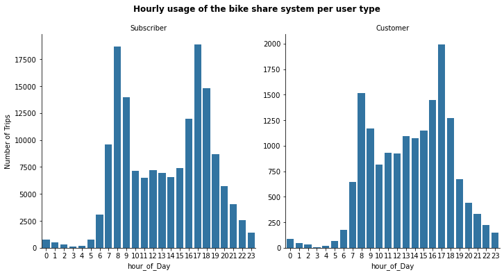

## Trip Duration and Age By User_Type

> In this investigation, I want to investigate the relationship between the trip duration and Age by the user type either subscriber or customer.

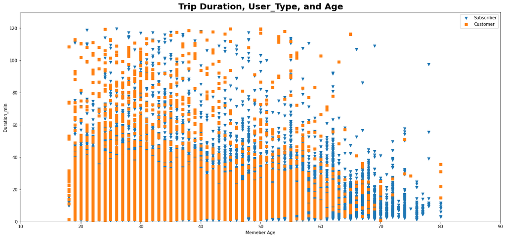

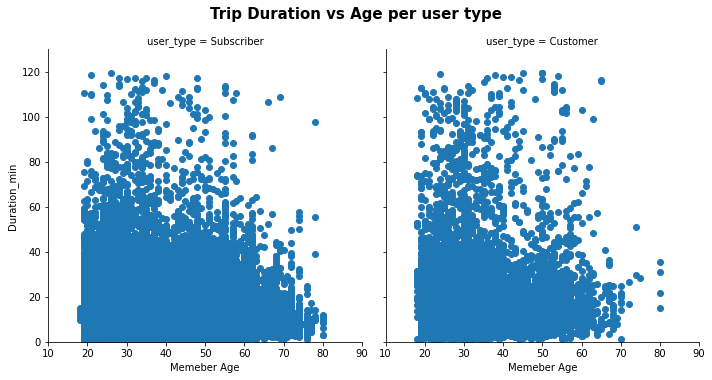